# Decision Trees

2024-04-23

# Decision Trees

Decision trees can be used for regression type problems or classification type problems. In the former case, they are called Regression Trees, and in the latter, Classification Trees.

## The Basics

```r
library(rpart) #We will use this library for decision trees
library(rpart.plot)
library(rattle) # We will use this library to print out a "fancy" tree
```

## Example - Regression Tree

```r
library(ISLR)
MyData <- Carseats[,1:8]
set.seed(2342)
Model1 = rpart(Sales~.,data=MyData,method="anova") # Use regression tree
summary(Model1)
```

```
## Call:
## rpart(formula = Sales ~ ., data = MyData, method = "anova")
##   n= 400
##
##            CP nsplit rel error    xerror       xstd
## 1  0.25051039      0 1.0000000 1.0085959 0.06965686
## 2  0.10507256      1 0.7494896 0.7597915 0.05157154
## 3  0.05112059      2 0.6444171 0.6731735 0.04558220
## 4  0.04567126      3 0.5932965 0.6375077 0.04162517
## 5  0.03359237      4 0.5476252 0.6051916 0.04158015
## 6  0.02406279      5 0.5140328 0.6209222 0.04222797
## 7  0.02394780      6 0.4899700 0.6362229 0.04162421
## 8  0.02216327      7 0.4660222 0.6287085 0.04171513
## 9  0.01604252      8 0.4438590 0.5965567 0.04024666
## 10 0.01402704      9 0.4278165 0.5905546 0.03972022
## 11 0.01314537     11 0.3997624 0.5889412 0.04016603
## 12 0.01271091     12 0.3866170 0.5873226 0.04032371
## 13 0.01214708     13 0.3739061 0.5805813 0.03988911
## 14 0.01188778     14 0.3617590 0.5748148 0.03931995
## 15 0.01077845     15 0.3498712 0.5744957 0.03873513
## 16 0.01050614     16 0.3390928 0.5778249 0.03820342
## 17 0.01000000     17 0.3285866 0.5799048 0.03752935
##
## Variable importance
##   ShelveLoc       Price   CompPrice Advertising      Income         Age
##          40          26           9           8           7           6
##  Population
##           4
##
## Node number 1: 400 observations,    complexity param=0.2505104
##   mean=7.496325, MSE=7.955687
##   left son=2 (315 obs) right son=3 (85 obs)
##   Primary splits:
##       ShelveLoc   splits as  LRL,       improve=0.25051040, (0 missing)
##       Price       < 94.5  to the right, improve=0.14251530, (0 missing)
##       Advertising < 7.5   to the left,  improve=0.07303226, (0 missing)
##       Age         < 61.5  to the right, improve=0.07120203, (0 missing)
##       Income      < 61.5  to the left,  improve=0.02840494, (0 missing)
##
## Node number 2: 315 observations,    complexity param=0.1050726
```

[output cut: 250 more lines]

```
##
## Node number 47: 21 observations
##   mean=10.73, MSE=2.120524
##
## Node number 50: 9 observations
##   mean=7.603333, MSE=1.091978
##
## Node number 51: 27 observations
##   mean=9.828889, MSE=2.409714
##
## Node number 78: 28 observations
##   mean=6.731786, MSE=2.571229
##
## Node number 79: 22 observations
##   mean=8.930455, MSE=0.8257862
```

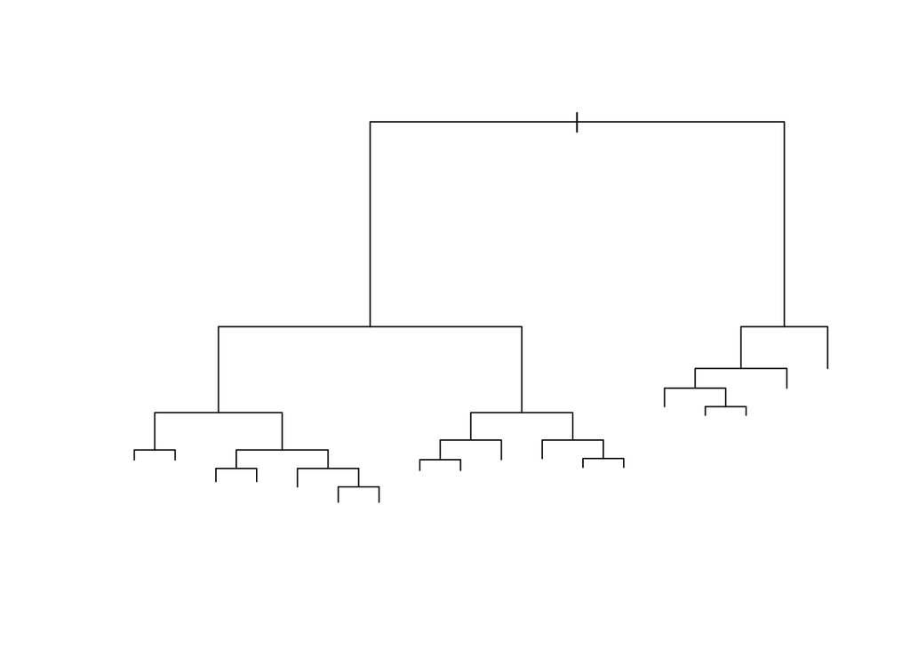

```r
plot(Model1)
```

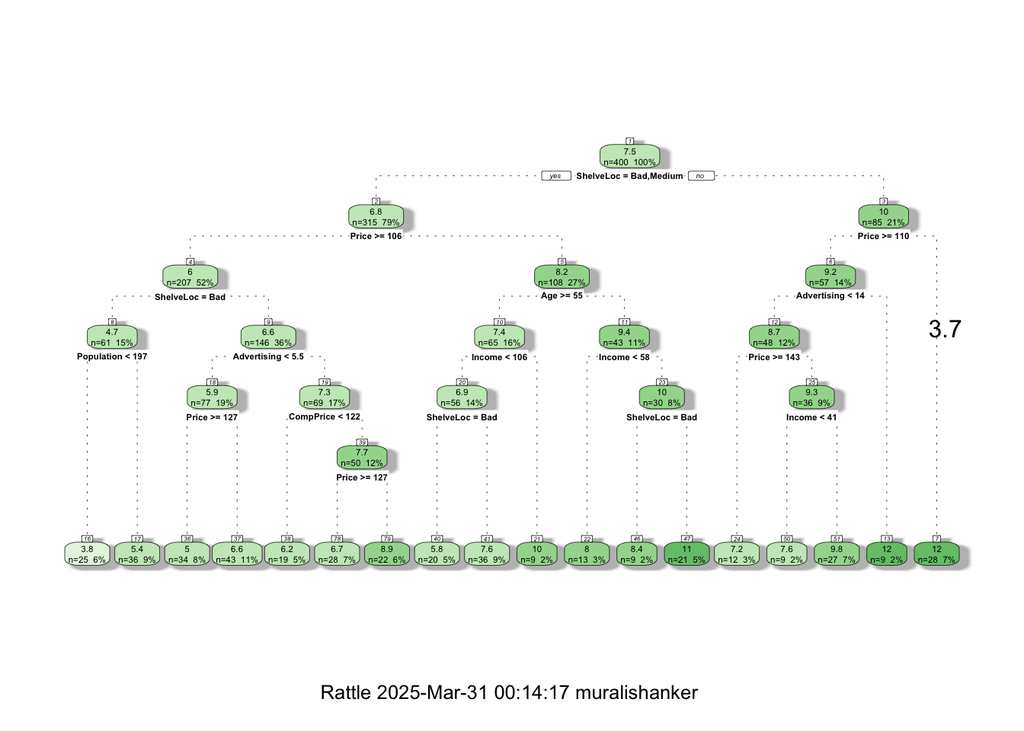

```r
fancyRpartPlot(Model1)
text(Model1)
```

*What is cp, or cost complexity pruning?*

$$\text{For each value of } \alpha \text{
there corresponds a subtree } T\subset T_0 \in \\
\sum_{m=1}^{|T|} \sum_{x_i \in R_m} (y_i - \hat{Y}_{R_m})^2 + \alpha|T|$$

Let us now use this information to prune the model

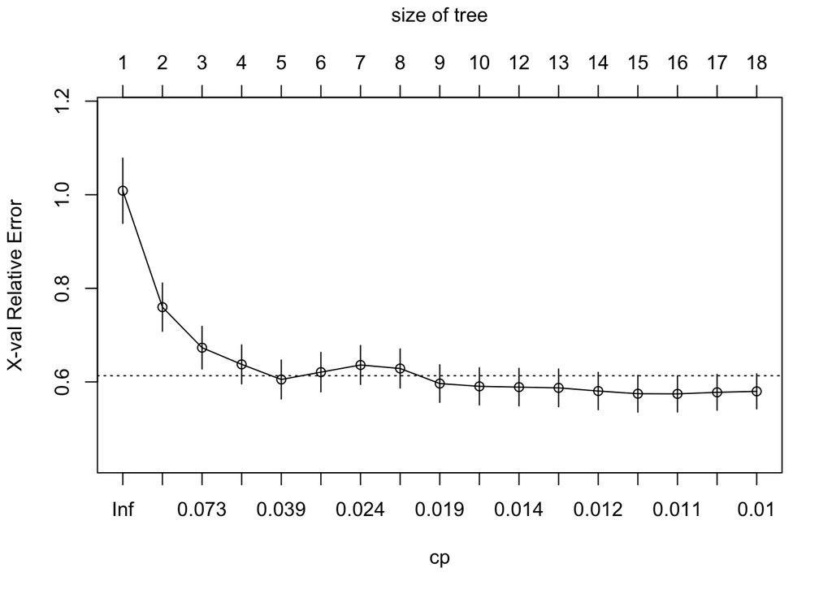

```r
plotcp(Model1)
```

```r
printcp(Model1)
```

```
##
## Regression tree:
## rpart(formula = Sales ~ ., data = MyData, method = "anova")
##
## Variables actually used in tree construction:
## [1] Advertising Age         CompPrice   Income      Population  Price
## [7] ShelveLoc
##
## Root node error: 3182.3/400 = 7.9557
##
## n= 400
##
##          CP nsplit rel error  xerror     xstd
## 1  0.250510      0   1.00000 1.00860 0.069657
## 2  0.105073      1   0.74949 0.75979 0.051572
## 3  0.051121      2   0.64442 0.67317 0.045582
## 4  0.045671      3   0.59330 0.63751 0.041625
## 5  0.033592      4   0.54763 0.60519 0.041580
## 6  0.024063      5   0.51403 0.62092 0.042228
## 7  0.023948      6   0.48997 0.63622 0.041624
## 8  0.022163      7   0.46602 0.62871 0.041715
## 9  0.016043      8   0.44386 0.59656 0.040247
## 10 0.014027      9   0.42782 0.59055 0.039720
## 11 0.013145     11   0.39976 0.58894 0.040166
## 12 0.012711     12   0.38662 0.58732 0.040324
## 13 0.012147     13   0.37391 0.58058 0.039889
## 14 0.011888     14   0.36176 0.57481 0.039320
## 15 0.010778     15   0.34987 0.57450 0.038735
## 16 0.010506     16   0.33909 0.57782 0.038203
## 17 0.010000     17   0.32859 0.57990 0.037529
```

```r
P_Model1 = prune.rpart(Model1,cp=0.03359237)
summary(P_Model1)
```

```
## Call:
## rpart(formula = Sales ~ ., data = MyData, method = "anova")
##   n= 400
##
##           CP nsplit rel error    xerror       xstd
## 1 0.25051039      0 1.0000000 1.0085959 0.06965686
## 2 0.10507256      1 0.7494896 0.7597915 0.05157154
## 3 0.05112059      2 0.6444171 0.6731735 0.04558220
## 4 0.04567126      3 0.5932965 0.6375077 0.04162517
## 5 0.03359237      4 0.5476252 0.6051916 0.04158015
##
## Variable importance
##  ShelveLoc      Price  CompPrice Population        Age
##         59         31          7          2          1
##
## Node number 1: 400 observations,    complexity param=0.2505104
##   mean=7.496325, MSE=7.955687
##   left son=2 (315 obs) right son=3 (85 obs)
##   Primary splits:
##       ShelveLoc   splits as  LRL,       improve=0.25051040, (0 missing)
##       Price       < 94.5  to the right, improve=0.14251530, (0 missing)
##       Advertising < 7.5   to the left,  improve=0.07303226, (0 missing)
##       Age         < 61.5  to the right, improve=0.07120203, (0 missing)
##       Income      < 61.5  to the left,  improve=0.02840494, (0 missing)
##
## Node number 2: 315 observations,    complexity param=0.1050726
##   mean=6.762984, MSE=5.903364
##   left son=4 (207 obs) right son=5 (108 obs)
##   Primary splits:
##       Price       < 105.5 to the right, improve=0.17981130, (0 missing)
##       ShelveLoc   splits as  L-R,       improve=0.11418740, (0 missing)
##       Advertising < 7.5   to the left,  improve=0.09324535, (0 missing)
##       Age         < 68.5  to the right, improve=0.06549277, (0 missing)
##       Income      < 60.5  to the left,  improve=0.04926766, (0 missing)
##   Surrogate splits:
##       CompPrice  < 113.5 to the right, agree=0.749, adj=0.269, (0 split)
##       Population < 507.5 to the left,  agree=0.667, adj=0.028, (0 split)
##       Income     < 22.5  to the right, agree=0.660, adj=0.009, (0 split)
##
## Node number 3: 85 observations,    complexity param=0.05112059
```

[output cut: 24 more lines]

```
##
## Node number 5: 108 observations
##   mean=8.189352, MSE=5.264976
##
## Node number 6: 57 observations
##   mean=9.244386, MSE=4.864302
##
## Node number 7: 28 observations
##   mean=12.18786, MSE=3.056331
##
## Node number 8: 61 observations
##   mean=4.722459, MSE=3.947864
##
## Node number 9: 146 observations
##   mean=6.560411, MSE=3.906946
```

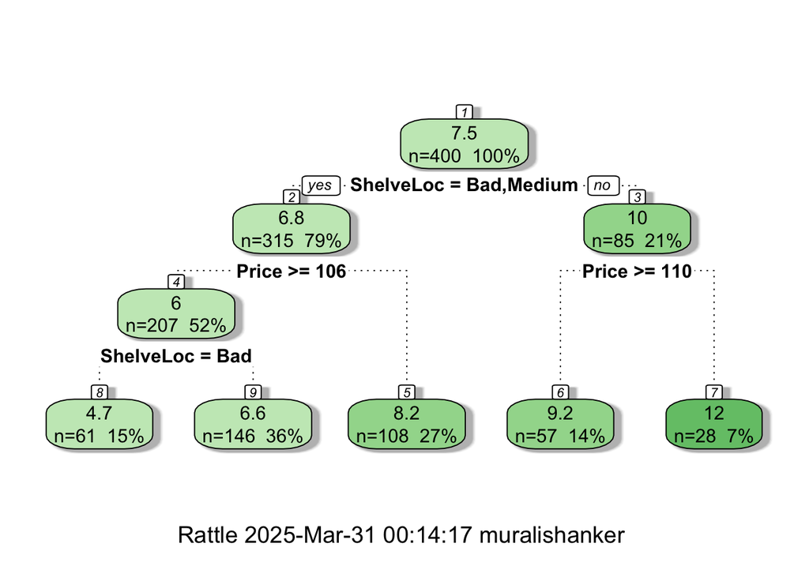

```r
fancyRpartPlot(P_Model1)
```

## Classification Trees

A classification tree is similar to a regression tree, except that it is used to predict a qualitative response rather than a quantitative one. In classification trees, we predict that each observation belongs to the *most commonly occuring class* of training observations in the region to which it belongs.

### Criteria

- Classification error rate

$$E = 1 - \max_k (\hat{p}_{mk}) \\ \text{
where } \hat{p}_{mk} \text{represents the proportion of training
observations in the mth region that are from the kth class}$$
* Gini Index

$$G = 1 - \sum_{k=1}^{K}
\hat{p}_{mk}^2$$

- Cross-entropy

$$D = -\sum_{k=1}^{K} \hat{p}_{mk}
log{(\hat{p}_{mk})}$$
### Example

```r
attach(MyData)
High = ifelse(Sales<=8, "No","Yes") # Create a qualitative response
MyData = data.frame(MyData,High)
ModelC = rpart(High~.-Sales,data=MyData,method="class")
ModelC
```

```
## n= 400
##
## node), split, n, loss, yval, (yprob)
##       * denotes terminal node
##
##   1) root 400 164 No (0.59000000 0.41000000)
##     2) ShelveLoc=Bad,Medium 315  98 No (0.68888889 0.31111111)
##       4) Price>=92.5 269  66 No (0.75464684 0.24535316)
##         8) Advertising< 13.5 224  41 No (0.81696429 0.18303571)
##          16) CompPrice< 124.5 96   6 No (0.93750000 0.06250000) *
##          17) CompPrice>=124.5 128  35 No (0.72656250 0.27343750)
##            34) Price>=109.5 107  20 No (0.81308411 0.18691589)
##              68) Price>=126.5 65   6 No (0.90769231 0.09230769) *
##              69) Price< 126.5 42  14 No (0.66666667 0.33333333)
##               138) Age>=49.5 22   2 No (0.90909091 0.09090909) *
##               139) Age< 49.5 20   8 Yes (0.40000000 0.60000000) *
##            35) Price< 109.5 21   6 Yes (0.28571429 0.71428571) *
##         9) Advertising>=13.5 45  20 Yes (0.44444444 0.55555556)
##          18) Age>=54.5 20   5 No (0.75000000 0.25000000) *
##          19) Age< 54.5 25   5 Yes (0.20000000 0.80000000) *
##       5) Price< 92.5 46  14 Yes (0.30434783 0.69565217)
##        10) Income< 57 10   3 No (0.70000000 0.30000000) *
##        11) Income>=57 36   7 Yes (0.19444444 0.80555556) *
##     3) ShelveLoc=Good 85  19 Yes (0.22352941 0.77647059)
##       6) Price>=142.5 12   3 No (0.75000000 0.25000000) *
##       7) Price< 142.5 73  10 Yes (0.13698630 0.86301370) *
```

```r
summary(ModelC)
```

```
## Call:
## rpart(formula = High ~ . - Sales, data = MyData, method = "class")
##   n= 400
##
##           CP nsplit rel error    xerror       xstd
## 1 0.28658537      0 1.0000000 1.0000000 0.05997967
## 2 0.10975610      1 0.7134146 0.7134146 0.05547692
## 3 0.04573171      2 0.6036585 0.6402439 0.05365767
## 4 0.03658537      4 0.5121951 0.6341463 0.05349198
## 5 0.02743902      5 0.4756098 0.6036585 0.05262923
## 6 0.02439024      7 0.4207317 0.5853659 0.05208331
## 7 0.01219512      8 0.3963415 0.5914634 0.05226769
## 8 0.01000000     10 0.3719512 0.6219512 0.05315381
##
## Variable importance
##       Price   ShelveLoc         Age Advertising   CompPrice      Income
##          35          25          11          11           9           5
##  Population
##           3
##
## Node number 1: 400 observations,    complexity param=0.2865854
##   predicted class=No   expected loss=0.41  P(node) =1
##     class counts:   236   164
##    probabilities: 0.590 0.410
##   left son=2 (315 obs) right son=3 (85 obs)
##   Primary splits:
##       ShelveLoc   splits as  LRL,       improve=28.991900, (0 missing)
##       Price       < 92.5  to the right, improve=19.463880, (0 missing)
##       Advertising < 6.5   to the left,  improve=17.277980, (0 missing)
##       Age         < 61.5  to the right, improve= 9.264442, (0 missing)
##       Income      < 60.5  to the left,  improve= 7.249032, (0 missing)
##
## Node number 2: 315 observations,    complexity param=0.1097561
##   predicted class=No   expected loss=0.3111111  P(node) =0.7875
##     class counts:   217    98
##    probabilities: 0.689 0.311
##   left son=4 (269 obs) right son=5 (46 obs)
##   Primary splits:
##       Price       < 92.5  to the right, improve=15.930580, (0 missing)
##       Advertising < 7.5   to the left,  improve=11.432570, (0 missing)
```

[output cut: 165 more lines]

```
##       Income      < 46.5  to the left,  agree=0.595, adj=0.15, (0 split)
##       CompPrice   < 131.5 to the right, agree=0.571, adj=0.10, (0 split)
##       Advertising < 5.5   to the left,  agree=0.571, adj=0.10, (0 split)
##       Population  < 221.5 to the left,  agree=0.571, adj=0.10, (0 split)
##       Price       < 116.5 to the left,  agree=0.571, adj=0.10, (0 split)
##
## Node number 138: 22 observations
##   predicted class=No   expected loss=0.09090909  P(node) =0.055
##     class counts:    20     2
##    probabilities: 0.909 0.091
##
## Node number 139: 20 observations
##   predicted class=Yes  expected loss=0.4  P(node) =0.05
##     class counts:     8    12
##    probabilities: 0.400 0.600
```

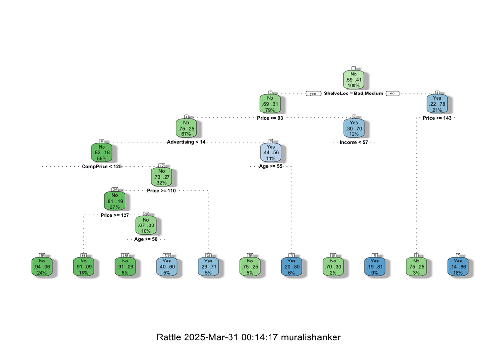

```r
fancyRpartPlot(ModelC)
```

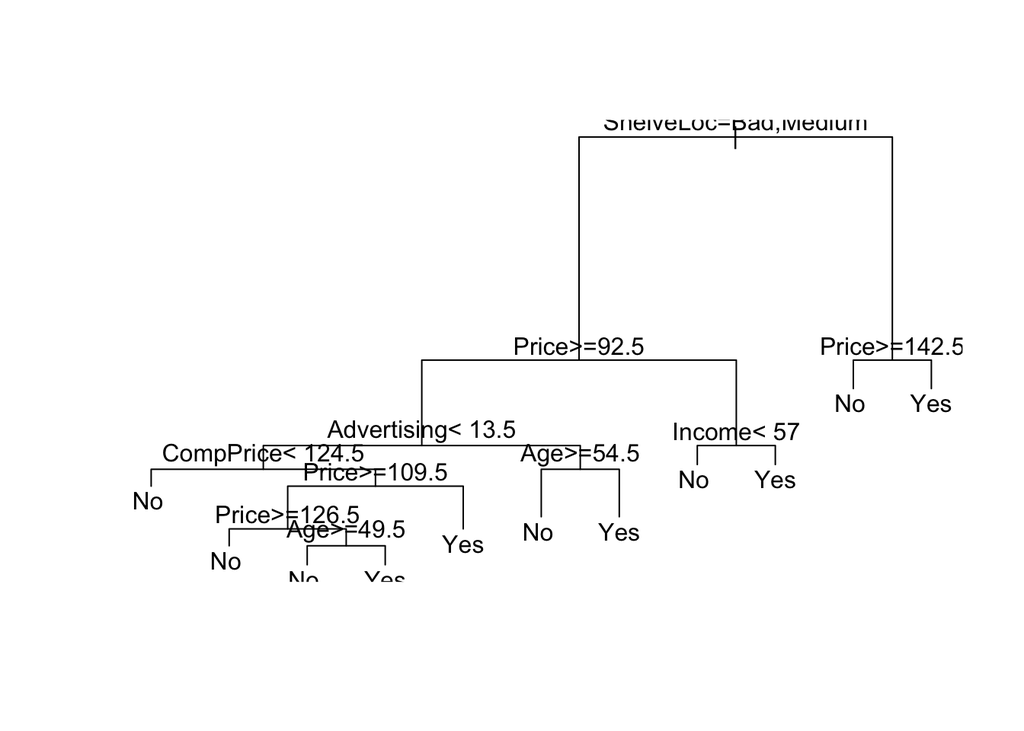

```r
plot(ModelC)
text(ModelC, pretty = 0)
```

Let’s apply this approach to a hold-out set

```r
set.seed(12)
training = sample(1:nrow(MyData),200)
MyData.train = MyData[training,]
MyData.test <- MyData[-training,]
ModelCa = rpart(High~.-Sales,data=MyData,subset=training,method="class")
summary(ModelCa)
```

```
## Call:
## rpart(formula = High ~ . - Sales, data = MyData, subset = training,
##     method = "class")
##   n= 200
##
##           CP nsplit rel error    xerror       xstd
## 1 0.28571429      0 1.0000000 1.0000000 0.08309490
## 2 0.17857143      1 0.7142857 0.8095238 0.07975302
## 3 0.07142857      2 0.5357143 0.5714286 0.07190319
## 4 0.02380952      4 0.3928571 0.4642857 0.06670386
## 5 0.01000000      6 0.3452381 0.4761905 0.06734350
##
## Variable importance
##       Price Advertising   ShelveLoc   CompPrice         Age      Income
##          38          27          21          10           2           1
##  Population
##           1
##
## Node number 1: 200 observations,    complexity param=0.2857143
##   predicted class=No   expected loss=0.42  P(node) =1
##     class counts:   116    84
##    probabilities: 0.580 0.420
##   left son=2 (168 obs) right son=3 (32 obs)
##   Primary splits:
##       Price       < 92.5  to the right, improve=15.773330, (0 missing)
##       ShelveLoc   splits as  LRL,       improve=15.054580, (0 missing)
##       Advertising < 8.5   to the left,  improve= 9.881667, (0 missing)
##       Age         < 61.5  to the right, improve= 5.230355, (0 missing)
##       Income      < 25.5  to the left,  improve= 1.798348, (0 missing)
##   Surrogate splits:
##       CompPrice < 103.5 to the right, agree=0.85, adj=0.063, (0 split)
##
## Node number 2: 168 observations,    complexity param=0.1785714
##   predicted class=No   expected loss=0.3333333  P(node) =0.84
##     class counts:   112    56
##    probabilities: 0.667 0.333
##   left son=4 (135 obs) right son=5 (33 obs)
##   Primary splits:
##       ShelveLoc   splits as  LRL,       improve=12.746130, (0 missing)
##       Advertising < 8.5   to the left,  improve= 9.782531, (0 missing)
```

[output cut: 81 more lines]

```
##       CompPrice   < 146.5 to the right, agree=0.783, adj=0.5, (0 split)
##       Age         < 60    to the right, agree=0.739, adj=0.4, (0 split)
##       Income      < 35.5  to the right, agree=0.696, adj=0.3, (0 split)
##       Advertising < 9.5   to the left,  agree=0.696, adj=0.3, (0 split)
##       Population  < 97.5  to the right, agree=0.652, adj=0.2, (0 split)
##
## Node number 34: 13 observations
##   predicted class=No   expected loss=0.2307692  P(node) =0.065
##     class counts:    10     3
##    probabilities: 0.769 0.231
##
## Node number 35: 10 observations
##   predicted class=Yes  expected loss=0.3  P(node) =0.05
##     class counts:     3     7
##    probabilities: 0.300 0.700
```

```r
ModelCa.predict = predict(ModelCa, MyData.test,type="class")
table(ModelCa.predict,MyData.test$High)
```

```
##
## ModelCa.predict No Yes
##             No  95  29
##             Yes 25  51
```

Let’s prune the tree based on cp value

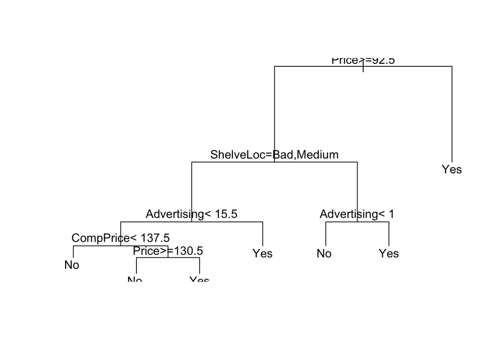

```r
ModelCa.prune <- prune.rpart(ModelCa,cp=0.02380952)
plot(ModelCa.prune)
text(ModelCa.prune,pretty = 0)
```

```r
ModelCa.prune.predict <- predict(ModelCa.prune,MyData.test,type="class")
table(ModelCa.prune.predict,MyData.test$High)
```

```
##
## ModelCa.prune.predict No Yes
##                   No  95  29
##                   Yes 25  51
```

### Using the Gini Index

```r
gini  <- function(tree){
  # calculate gini index for `rpart` tree
  ylevels <- attributes(tree)[["ylevels"]]
  nclass <- length(ylevels)
  yval2 <- tree[["frame"]][["yval2"]]
  vars <- tree[["frame"]][["var"]]
  labls = labels(tree)
  df = data.frame(matrix(nrow=length(labls), ncol=5))
  colnames(df) <- c("Name", "GiniIndex", "Class", "Items", "ItemProbs")

  for(i in 1:length(vars)){
    row <- yval2[i , ]
    node.class <- row[1]
    j <- 2
    node.class_counts = row[j:(j+nclass-1)]
    j <- j+nclass
    node.class_probs = row[j:(j+nclass-1)]

    gini = 1-sum(node.class_probs^2)
    gini = round(gini,5)
    name = paste(vars[i], " (", labls[i], ")")
    df[i,] = c(name, gini, node.class, toString(round(node.class_counts,5)), toString(round(node.class_probs,5)))
  }
  return(df)
}
gini(ModelCa)
```

```
##                                Name GiniIndex Class   Items        ItemProbs
## 1                   Price  ( root )    0.4872     1 116, 84       0.58, 0.42
## 2        ShelveLoc  ( Price>=92.5 )   0.44444     1 112, 56 0.66667, 0.33333
## 3     Advertising  ( ShelveLoc=ac )    0.3617     1 103, 32 0.76296, 0.23704
## 4  CompPrice  ( Advertising< 15.5 )   0.28344     1  97, 20 0.82906, 0.17094
## 5      <leaf>  ( CompPrice< 137.5 )   0.19013     1  84, 10 0.89362, 0.10638
## 6       Price  ( CompPrice>=137.5 )   0.49149     1  13, 10 0.56522, 0.43478
## 7          <leaf>  ( Price>=130.5 )   0.35503     1   10, 3 0.76923, 0.23077
## 8          <leaf>  ( Price< 130.5 )      0.42     2    3, 7         0.3, 0.7
## 9     <leaf>  ( Advertising>=15.5 )   0.44444     2   6, 12 0.33333, 0.66667
## 10     Advertising  ( ShelveLoc=b )   0.39669     2   9, 24 0.27273, 0.72727
## 11       <leaf>  ( Advertising< 1 )   0.21875     1    7, 1     0.875, 0.125
## 12       <leaf>  ( Advertising>=1 )    0.1472     2   2, 23       0.08, 0.92
## 13          <leaf>  ( Price< 92.5 )   0.21875     2   4, 28     0.125, 0.875
```